# Collaboration and Competition

You are welcome to use this coding environment to train your agent for the project. Follow the instructions below to get started!

### 1. Start the Environment

Run the next code cell to install a few packages. This line will take a few minutes to run!

```python
#!pip -q install ./python
#!pip -q install tqdm
```

The environment is already saved in the Workspace and can be accessed at the file path provided below.

```python
from unityagents import UnityEnvironment
import numpy as np
import pandas as pd
from tqdm import tnrange, tqdm_notebook
import seaborn as sns
sns.set

#env = UnityEnvironment(file_name="/data/Tennis_Linux_NoVis/Tennis")
env = UnityEnvironment(file_name="Tennis.app")
train = True
```

```
INFO:unityagents:
'Academy' started successfully!
Unity Academy name: Academy
        Number of Brains: 1
        Number of External Brains : 1
        Lesson number : 0
        Reset Parameters :

Unity brain name: TennisBrain
        Number of Visual Observations (per agent): 0
        Vector Observation space type: continuous
        Vector Observation space size (per agent): 8
        Number of stacked Vector Observation: 3
        Vector Action space type: continuous
        Vector Action space size (per agent): 2
        Vector Action descriptions: ,
```

Environments contain *brains* which are responsible for deciding the actions of their associated agents. Here we check for the first brain available, and set it as the default brain we will be controlling from Python.

```python
# get the default brain
brain_name = env.brain_names[0]
brain = env.brains[brain_name]
```

### 2. Examine the State and Action Spaces

Run the code cell below to print some information about the environment.

```python
# reset the environment
env_info = env.reset(train_mode=True)[brain_name]

# number of agents
num_agents = len(env_info.agents)
print('Number of agents:', num_agents)

# size of each action
action_size = brain.vector_action_space_size
print('Size of each action:', action_size)

# examine the state space
states = env_info.vector_observations
state_size = states.shape[1]
print('There are {} agents. Each observes a state with length: {}'.format(states.shape[0], state_size))
print('The state for the first agent looks like:', states[0])
```

```
Number of agents: 2
Size of each action: 2
There are 2 agents. Each observes a state with length: 24
The state for the first agent looks like: [ 0.          0.          0.          0.          0.          0.
  0.          0.          0.          0.          0.          0.
  0.          0.          0.          0.         -6.65278625 -1.5
 -0.          0.          6.83172083  6.         -0.          0.        ]
```

### 3. Take Random Actions in the Environment

In the next code cell, you will learn how to use the Python API to control the agent and receive feedback from the environment.

Note that **in this coding environment, you will not be able to watch the agents while they are training**, and you should set `train_mode=True` to restart the environment.

```python
'''
for i in range(5):                                         # play game for 5 episodes
    env_info = env.reset(train_mode=False)[brain_name]     # reset the environment
    states = env_info.vector_observations                  # get the current state (for each agent)
    scores = np.zeros(num_agents)                          # initialize the score (for each agent)
    while True:
        actions = np.random.randn(num_agents, action_size) # select an action (for each agent)
        actions = np.clip(actions, -1, 1)                  # all actions between -1 and 1
        env_info = env.step(actions)[brain_name]           # send all actions to tne environment
        next_states = env_info.vector_observations         # get next state (for each agent)
        rewards = env_info.rewards                         # get reward (for each agent)
        dones = env_info.local_done                        # see if episode finished
        scores += env_info.rewards                         # update the score (for each agent)
        states = next_states                               # roll over states to next time step
        if np.any(dones):                                  # exit loop if episode finished
            break
    print('Total score (averaged over agents) this episode: {}'.format(np.mean(scores)))
'''
```

[output not shown]

# Initialize Agents

```python
# Load the Agent from the ddpg_agent file
from maddpg_agent import Agent, ReplayBuffer
from collections import deque
import torch
import torch.nn.functional as F
import torch.optim as optim
device = torch.device("cuda:0" if torch.cuda.is_available() else "cpu")
from model import Actor, Critic

import matplotlib.pyplot as plt
%matplotlib inline

# initialize the agent and the environment
#[Agent(state_size=state_size, action_size=action_size, random_seed=0, memory = memory, critic_target = critic_target) for count in range(num_agents)]

# Initialize agent and shared memory (for multi-agent use)
BUFFER_SIZE = int(1e6)  # replay buffer size
BATCH_SIZE = 256        # minibatch size
random_seed = 42

actor_target = Actor(state_size, action_size, random_seed).to(device)
critic_target = Critic(state_size, action_size, random_seed).to(device)

memory = ReplayBuffer(action_size, BUFFER_SIZE, BATCH_SIZE, random_seed)
agents = [Agent(state_size=state_size, action_size=action_size, random_seed=random_seed,
                memory = memory, actor_target = actor_target)for _ in range(num_agents)]
```

# Train the Agents

```python
#training function
def ddpg(n_episodes=2500, max_t=1000, PRINT_EVERY=100):
    reached = False
    scores_deque = deque(maxlen=100)

    max_score = -np.Inf
    eps = tnrange(1, n_episodes+1)                             # counter for episodes (for time eval)
    for i_episode in eps:
        global data
        global thresh
        env_info = env.reset(train_mode=True)[brain_name]      # reset the environment
        states = env_info.vector_observations                  # get the current state (for each agent)
        scores = np.zeros(num_agents)                          # initialize the score (for each agent)
        [agents[i].reset() for i in range(num_agents)]
        #steps = tnrange(max_t, leave = False)                  # counter for steps (for time eval)
        steps = range(max_t)
        for t in steps:
            # write last score to counter
            #print(t)
            actions = [agents[i].act(states[i]) for i in range(num_agents)] # calculate next action with actor net
            dings.append(actions)
            #print(actions)
            f = actions[0][0].tolist()
            s = actions[1][0].tolist()
            actions = list([f,s])
            actions = np.clip(actions, -1, 1)
            #print(actions)
            env_info = env.step(actions)[brain_name]           # send all actions to tne environment
            next_states = env_info.vector_observations         # get next state (for each agent)
            rewards = env_info.rewards                         # get reward (for each agent)
            dones = env_info.local_done                        # see if episode finished
            [agents[i].step(states[i], actions[i], rewards[i], next_states[i], dones[i]) for i in range(num_agents)]
            states = next_states
            scores += rewards
            if np.any(dones):
                break

        score = np.max(scores)                                # save scores for evaluation
        scores_deque.append(score)
        scores_hist.append(score)

        data = data.append({"episode": i_episode, "score":score, "avg" : np.mean(scores_deque)}, ignore_index=True)
        eps.set_description("max score is %f, avg is %f" % (score, data.iloc[-1]["avg"]))

        if i_episode % PRINT_EVERY == 0:
            print('\rEpisode {}\tMax Score: {:.2f}\tAverage over last 100: {:.2f}'.format(i_episode, np.max(scores_deque), np.mean(scores_deque)))
        if (np.mean(scores_deque) > thresh + 0.1):
            print('\nEnvironment solved in {:d} episodes!\tAverage Score: {:.2f}'.format(i_episode, np.max(scores_deque)))
            torch.save(agents[0].actor_local.state_dict(), 'saved_models/checkpoint_actor_new.pth')
            torch.save(agents[0].critic_local.state_dict(), 'saved_models/checkpoint_critic_new.pth')
            thresh = np.max(scores_deque)
            reached = True
            #break

    return scores_hist, agents[0]
```

```python
if train:
    dings = []
    scores_hist = []
    data = pd.DataFrame(columns=["episode", "score", "avg"])
    thresh = 0.4
    scores, agent = ddpg()
    import pandas as pd
```

```
Episode 100	Max Score: 0.10	Average over last 100: 0.00
Episode 200	Max Score: 0.10	Average over last 100: 0.01
Episode 300	Max Score: 0.10	Average over last 100: 0.03
Episode 400	Max Score: 0.10	Average over last 100: 0.04
Episode 500	Max Score: 0.10	Average over last 100: 0.06
Episode 600	Max Score: 0.10	Average over last 100: 0.07
Episode 700	Max Score: 0.10	Average over last 100: 0.08
Episode 800	Max Score: 0.10	Average over last 100: 0.07
Episode 900	Max Score: 0.20	Average over last 100: 0.09
Episode 1000	Max Score: 0.40	Average over last 100: 0.10
Episode 1100	Max Score: 0.40	Average over last 100: 0.11
Episode 1200	Max Score: 0.60	Average over last 100: 0.13
Episode 1300	Max Score: 0.40	Average over last 100: 0.16
Episode 1400	Max Score: 0.80	Average over last 100: 0.18
Episode 1500	Max Score: 2.10	Average over last 100: 0.22
Episode 1600	Max Score: 1.80	Average over last 100: 0.22
Episode 1700	Max Score: 2.10	Average over last 100: 0.25
Episode 1800	Max Score: 2.60	Average over last 100: 0.32

Environment solved in 1883 episodes!	Average Score: 2.60
Episode 1900	Max Score: 2.70	Average over last 100: 0.59
Episode 2000	Max Score: 2.70	Average over last 100: 0.55
Episode 2100	Max Score: 2.60	Average over last 100: 0.23
Episode 2200	Max Score: 2.60	Average over last 100: 0.17
Episode 2300	Max Score: 2.50	Average over last 100: 0.25
Episode 2400	Max Score: 2.60	Average over last 100: 0.38
Episode 2500	Max Score: 2.60	Average over last 100: 0.39
```

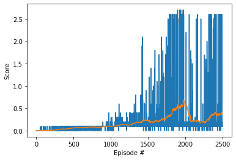

```python
if train:
    fig = plt.figure()
    ax = fig.add_subplot(111)
    plt.plot(np.arange(1, len(scores_hist)+1), scores_hist)
    plt.plot(np.arange(1, len(scores_hist)+1), data["avg"])
    #plt.plot(x = np.arange(1, len(scores)+1), y = 30, data = data)
    plt.ylabel('Score')
    plt.xlabel('Episode #')
    plt.show()
```

```python
import time
train = False
if train == False:
    n_episodes = 100 # number of runs
    max_t = 1000   # max number of steps to solve env
    score_hist = []
    # load the trained agent
    for agent in agents:
        agent.actor_local.load_state_dict(torch.load('saved_models/checkpoint_actor_new.pth',map_location='cpu'))
        agent.critic_local.load_state_dict(torch.load('saved_models/checkpoint_critic_new.pth',map_location='cpu'))

    # iterate over runs
    for i_episode in range(1, n_episodes+1):

        # get environment infos and set first state
        env_info = env.reset(train_mode=True)[brain_name]      # reset the environment
        states = env_info.vector_observations                  # get the current state (for each agent)
        scores = np.zeros(num_agents)                          # initialize the score (for each agent)
        # run until finished or max steps
        for t in range(max_t):

            actions = [agents[i].act(states[i]) for i in range(num_agents)] # calculate next action with actor net
            first = actions[0][0].tolist()
            second = actions[1][0].tolist()
            actions = list([first,second])
            actions = np.clip(actions, -1, 1)
            env_info = env.step(actions)[brain_name]           # send all actions to tne environment
            next_states = env_info.vector_observations         # get next state (for each agent)
            rewards = env_info.rewards                         # get reward (for each agent)
            dones = env_info.local_done                        # see if episode finished
            states = next_states
            scores += rewards

            # update environment info

            #time.sleep(0.006) # makes actions visable for humans (~60 fps)
            print('\rScore: {:.2f}'.format(np.max(scores)), end="")
            if np.any(dones):
                break
        score_hist.append(scores)
        print('\nScore: {:.2f}\tcurrent average: {:.2f}'.format(np.max(scores), np.mean(score_hist)), end="")
```

```
Score: 0.10
Score: 2.60	current average: 0.05
Score: 0.10	current average: 1.30
Score: 0.10	current average: 0.88
Score: 0.09	current average: 0.67
Score: 0.10	current average: 0.55
Score: 0.00	current average: 0.46
Score: 0.19	current average: 0.40
Score: 0.20	current average: 0.36
Score: 0.09	current average: 0.34
Score: 0.00	current average: 0.31
Score: 0.10	current average: 0.28
Score: 0.10	current average: 0.26
Score: 2.60	current average: 0.25
Score: 2.60	current average: 0.41
Score: 2.60	current average: 0.56
Score: 2.60	current average: 0.68
Score: 2.60	current average: 0.80
Score: 2.70	current average: 0.90
Score: 2.60	current average: 0.99
Score: 2.60	current average: 1.07
Score: 2.70	current average: 1.14
Score: 2.60	current average: 1.21
Score: 0.10	current average: 1.27
Score: 0.09	current average: 1.22
Score: 0.10	current average: 1.17
Score: 2.60	current average: 1.13
Score: 0.10	current average: 1.18
Score: 0.10	current average: 1.14
Score: 0.10	current average: 1.10
Score: 0.10	current average: 1.07
Score: 2.60	current average: 1.04
Score: 0.20	current average: 1.08
Score: 0.19	current average: 1.05
Score: 0.10	current average: 1.03
Score: 0.20	current average: 1.00
Score: 0.09	current average: 0.97
Score: 0.10	current average: 0.95
Score: 0.10	current average: 0.93
Score: 0.10	current average: 0.90
```

[output cut: 20 more lines]

```
Score: 2.60	current average: 0.86
Score: 0.20	current average: 0.89
Score: 0.10	current average: 0.88
Score: 0.09	current average: 0.87
Score: 0.10	current average: 0.85
Score: 0.10	current average: 0.84
Score: 0.00	current average: 0.83
Score: 0.10	current average: 0.82
Score: 0.10	current average: 0.81
Score: 0.10	current average: 0.80
Score: 2.60	current average: 0.78
Score: 0.10	current average: 0.81
Score: 2.60	current average: 0.80
Score: 2.70	current average: 0.82
Score: 2.00	current average: 0.85
```

When finished, you can close the environment.

```python
#env.close()
```

### 4. It's Your Turn!

Now it's your turn to train your own agent to solve the environment! A few **important notes**:

- When training the environment, set `train_mode=True`, so that the line for resetting the environment looks like the following:

  ```
  env_info = env.reset(train_mode=True)[brain_name]
  ```

- To structure your work, you're welcome to work directly in this Jupyter notebook, or you might like to start over with a new file! You can see the list of files in the workspace by clicking on *Jupyter* in the top left corner of the notebook.
- In this coding environment, you will not be able to watch the agents while they are training. However, *after training the agents*, you can download the saved model weights to watch the agents on your own machine!